# ConQuR Package Vignette

Wodan Ling and Michael C. Wu

# Overview

The ConQuR package (v1.0) contains functions that conduct batch effects removal from **a taxa read count table** by a conditional quantile regression method. The distributional attributes of microbiome data - zero-inflation and over-dispersion, are simultaneously considered. To achieve the maximum removal of batch effects, a function tuning among the variations of ConQuR is provided. Supporting functions to compute PERMANOVA R$^2$, print PCoA plot and predict key variables based on a taxa read count table are also provided.

The following packages are required for functions and examples in the ZINQ package: quantreg, cqrReg, glmnet, dplyr, doParallel, gplots, vegan, ade4, compositions, randomForest, ROCR, ape, GUniFrac.

```r
library(ConQuR)
library(doParallel)
```

# Implementation of ConQuR

## Sample data

We will use the sample data in the package to demonstrate how to use ConQuR. The data 100 taxa from 273 samples, which were sequenced in 3 batches. There are batchid (factor), and the metadata: sbp (systolic blood pressure, the key variable, continuous), sex (covariate 1, binary), race (covariate 2, binary) and age (covariate 3, continuous).

```r
data(Sample_Data)

taxa = Sample_Data[, 1:100]
str(taxa)
```

```
#> 'data.frame':    273 obs. of  100 variables:
#>  $ Abiotrophia                       : int  0 0 0 0 0 2 2 0 0 0 ...
#>  $ Acetitomaculum                    : int  3 1 5 3 3 1 0 5 9 15 ...
#>  $ Acidaminobacter                   : int  1 0 1 0 5 0 2 0 2 0 ...
#>  $ Actinobaculum                     : int  0 0 0 0 0 0 0 0 0 0 ...
#>  $ Actinotignum                      : int  0 0 0 0 0 0 0 0 0 0 ...
#>  $ Aggregatibacter                   : int  0 0 0 0 0 0 0 0 0 0 ...
#>  $ Akkermansia                       : int  490 76 3 6 2515 629 9582 10 1517 106 ...
#>  $ Alkalibacter                      : int  0 0 0 0 0 0 0 0 0 0 ...
#>  $ Alloprevotella                    : int  95 6 11 6 12 6 5 12 2 2011 ...
#>  $ Alloscardovia                     : int  0 0 0 0 0 0 0 0 0 0 ...
#>  $ Anaeroglobus                      : int  0 1 2 0 0 0 1 0 2 0 ...
#>  $ Anaeroplasma                      : int  0 0 0 3 0 0 0 0 0 0 ...
#>  $ Anaerosolibacter                  : int  0 0 0 0 0 0 0 0 0 0 ...
#>  $ Anaerostipes                      : int  2067 298 1644 2056 101 78 291 2494 1087 954 ...
```

[output cut: 86 more lines]

```r
batchid = Sample_Data[, 'batchid']
summary(batchid)
```

```
#>  0  1  2
#> 94 86 93
```

```r
covar = Sample_Data[, c('sex', 'race', 'age', 'sbp')]
summary(covar)
```

```
#>  sex     race         age             sbp
#>  0:126   0:123   Min.   :48.00   Min.   : 80.54
#>  1:147   1:150   1st Qu.:53.00   1st Qu.:107.42
#>                  Median :56.00   Median :119.90
#>                  Mean   :55.18   Mean   :119.52
#>                  3rd Qu.:58.00   3rd Qu.:129.50
#>                  Max.   :60.00   Max.   :175.58
```

## Use of ConQuR

We first use ConQuR (default setting) to remove batch effects from the taxa read count table.

```r
options(warn=-1)
taxa_corrected = ConQuR(tax_tab=taxa, batchid=batchid, covariates=covar, batch_ref="0")
str(taxa_corrected)
```

```
#>  num [1:273, 1:100] 0 0 0 0 0 2 2 0 0 0 ...
#>  - attr(*, "dimnames")=List of 2
#>   ..$ : chr [1:273] "1" "106" "211" "315" ...
#>   ..$ : chr [1:100] "Abiotrophia" "Acetitomaculum" "Acidaminobacter" "Actinobaculum" ...
```

## Check how ConQuR works

Next, we compare the corrected taxa read count table to the original one, checking whether the batch effects are mitigated.

### Whether the PCoA plot is more unified w.r.t. batchid

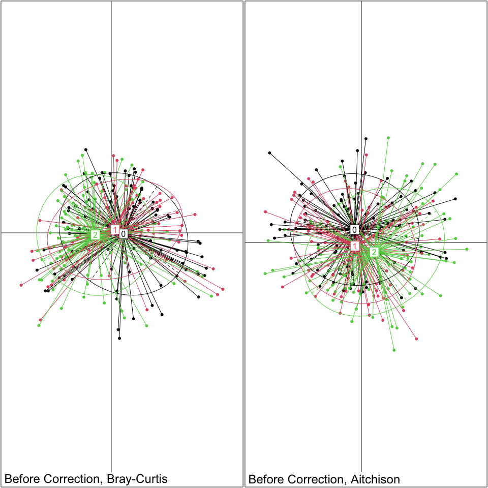

```r
par(mfrow=c(1, 2))
Plot_PCoA(TAX=taxa, factor=batchid, main="Before Correction, Bray-Curtis")
Plot_PCoA(TAX=taxa, factor=batchid, dissimilarity="Aitch",  main="Before Correction, Aitchison")
```

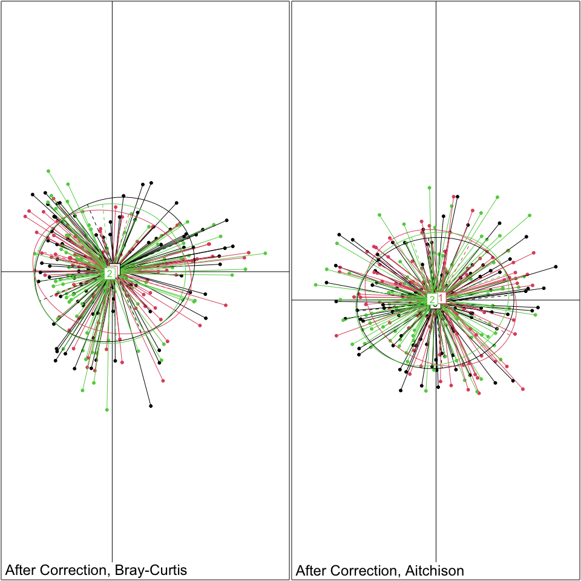

```r
par(mfrow=c(1, 2))
Plot_PCoA(TAX=taxa_corrected, factor=batchid, main="After Correction, Bray-Curtis")
Plot_PCoA(TAX=taxa_corrected, factor=batchid, dissimilarity="Aitch",  main="After Correction, Aitchison")
```

### Whether the variability explained by batchid (quantified by PERMANOVA R$^2$) is decreased

In the original taxa read count table:

```r
PERMANOVA_R2(TAX=taxa, batchid=batchid, covariates=covar, key_index=4)
```

```
#> $tab_count
#>          standard sqrt.dist=T       add=T
#> batch 0.039984533 0.025595993 0.015353159
#> key   0.009755741 0.007050036 0.005166912
#>
#> $tab_rel
#>         standard sqrt.dist=T       add=T
#> batch 0.01793771 0.012759139 0.009308747
#> key   0.01170220 0.007995517 0.005159427
```

In the corrected taxa read count table:

```r
PERMANOVA_R2(TAX=taxa_corrected, batchid=batchid, covariates=covar, key_index=4)
```

```
#> $tab_count
#>           standard sqrt.dist=T       add=T
#> batch 0.0003541554 0.003824281 0.005509695
#> key   0.0103524031 0.007380041 0.005434688
#>
#> $tab_rel
#>           standard sqrt.dist=T       add=T
#> batch 0.0006135316 0.004099607 0.005978398
#> key   0.0116378359 0.008041595 0.005300239
```

### Whether the corrected taxa read count table can better predict the key variable

Based on the original taxa read count table:

```r
sbp = covar[, 'sbp']
temp = RF_Pred_Regression(TAX=taxa, variable=sbp, main="RMSE of Predicting sbp by the Original")
```

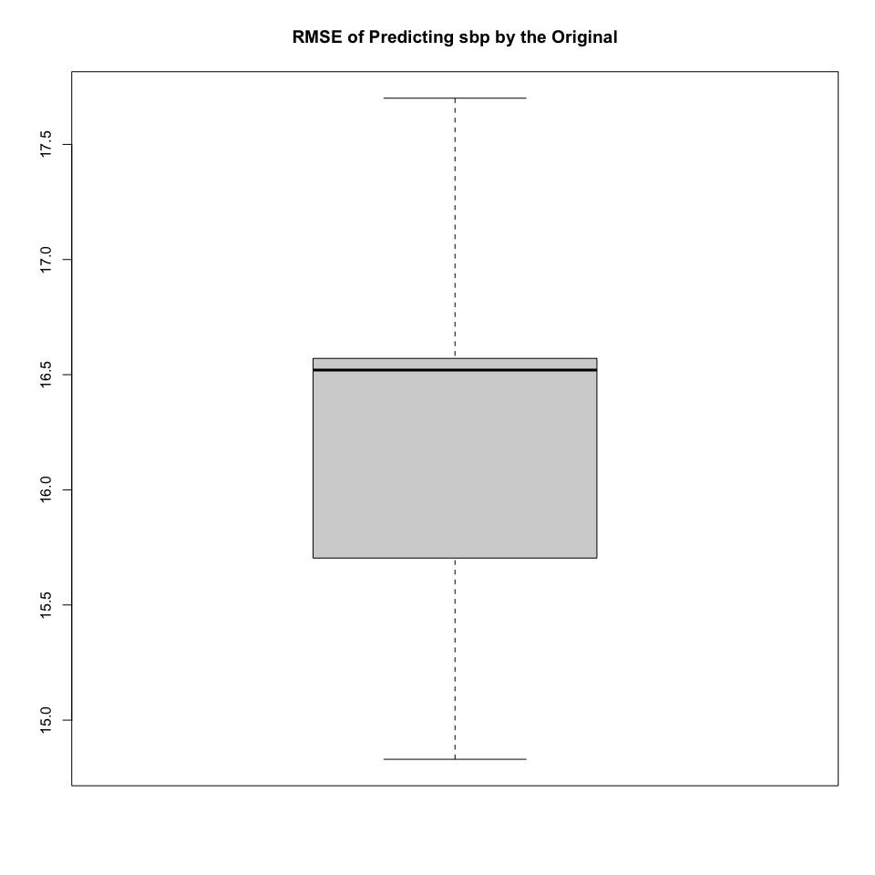

```r
temp$rmse_across_fold
```

```
#> [1] 15.70364 17.70054 16.52009 16.57068 14.82985
```

Based on the corrected taxa read count table:

```r
temp = RF_Pred_Regression(TAX=taxa_corrected, variable=sbp, main="RMSE of Predicting sbp by the Corrected")
```

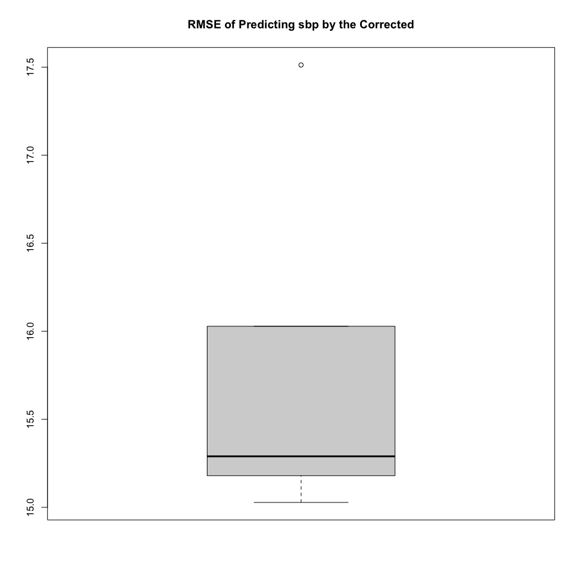

```r
temp$rmse_across_fold
```

```
#> [1] 15.28957 17.51225 15.17962 16.02835 15.02778
```

## Use of Tune_ConQuR

Tune among specified variations of ConQuR, and check the final variation selected in each cutoff:

```r
result_tuned = Tune_ConQuR(tax_tab=taxa, batchid=batchid, covariates=covar,
                           batch_ref_pool=c("0", "1"),
                           logistic_lasso_pool=F,
                           quantile_type_pool=c("standard", "lasso"),
                           simple_match_pool=F,
                           lambda_quantile_pool=c(NA, "2p/n"),
                           interplt_pool=F,
                           frequencyL=0,
                           frequencyU=1)

result_tuned$method_final
```

```
#>                0-0.1  0.1-0.2    0.2-0.3 0.3-0.4 0.4-0.5    0.5-0.6 0.6-0.7    0.7-0.8 0.8-0.9 0.9-1
#> batch_ref      NA     "0"        NA      "0"     "0"        NA      "0"        "0"     "0"     "0"
#> original       "TRUE" "FALSE"    "TRUE"  "FALSE" "FALSE"    "TRUE"  "FALSE"    "FALSE" "FALSE" "FALSE"
#> simple_match   NA     "FALSE"    NA      "FALSE" "FALSE"    NA      "FALSE"    "FALSE" "FALSE" "FALSE"
#> logistic_lasso NA     "FALSE"    NA      "FALSE" "FALSE"    NA      "FALSE"    "FALSE" "FALSE" "FALSE"
#> quantile_type  NA     "standard" NA      "lasso" "standard" NA      "standard" "lasso" "lasso" "lasso"
#> lambda         NA     "NA"       NA      "2p/n"  "NA"       NA      "NA"       "2p/n"  "2p/n"  "2p/n"
#> interplt       NA     "FALSE"    NA      "FALSE" "FALSE"    NA      "FALSE"    "FALSE" "FALSE" "FALSE"
```

Check the fine-tuned correcte taxa read count table:

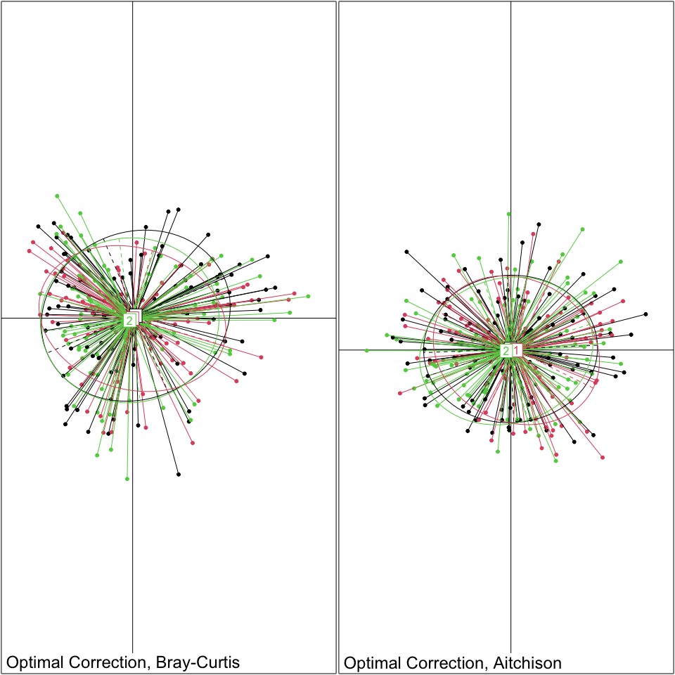

```r
taxa_optimal = result_tuned$tax_final

par(mfrow=c(1, 2))
Plot_PCoA(TAX=taxa_optimal, factor=batchid, main="Optimal Correction, Bray-Curtis")
Plot_PCoA(TAX=taxa_optimal, factor=batchid, dissimilarity="Aitch",  main="Optimal Correction, Aitchison")
```